# Statistics Project 2

## Dataset description

MASS (version 7.3-58.1)

## Boston: Housing Values in Suburbs of Boston

The Boston data frame has 506 rows and 14 columns.

The data frame contains the following columns:

- crim

per capita crime rate by town.

- zn

proportion of residential land zoned for lots over 25,000 sq.ft.

- indus

proportion of non-retail business acres per town.

- chas

Charles River dummy variable (= 1 if tract bounds river; 0 otherwise).

- nox

nitrogen oxides concentration (parts per 10 million).

- rm

average number of rooms per dwelling.

- age

proportion of owner-occupied units built prior to 1940.

- dis

weighted mean of distances to five Boston employment centres.

- rad

index of accessibility to radial highways.

- tax

full-value property-tax rate per $10,000.

- ptratio

pupil-teacher ratio by town.

- black

1000(Bk - 0.63)^2 where Bk is the proportion of blacks by town.

- lstat

lower status of the population (percent).

- medv

median value of owner-occupied homes in $1000s.

```python
import pandas as pd
import numpy as np
import seaborn as sns
import matplotlib.pyplot as plt
import statsmodels.api as sm
import statsmodels.formula.api as smf

from scipy.stats import ttest_ind, mannwhitneyu
# from sklearn.datasets import fetch_california_housing
```

```python
!gdown 1Yer3hkJSClsLwAFb9nOeuI_YcCwYOdbg
df = pd.read_csv("/content/BostonHousing.csv")
```

```
Downloading...
From: https://drive.google.com/uc?id=1Yer3hkJSClsLwAFb9nOeuI_YcCwYOdbg
To: /content/BostonHousing.csv
100% 35.7k/35.7k [00:00<00:00, 40.7MB/s]
```

```python
df.head()
```

|  | crim | zn | indus | chas | nox | rm | age | dis | rad | tax | ptratio | b | lstat | medv |
| --- | --- | --- | --- | --- | --- | --- | --- | --- | --- | --- | --- | --- | --- | --- |
| 0 | 0.00632 | 18.0 | 2.31 | 0 | 0.538 | 6.575 | 65.2 | 4.0900 | 1 | 296 | 15.3 | 396.90 | 4.98 | 24.0 |
| 1 | 0.02731 | 0.0 | 7.07 | 0 | 0.469 | 6.421 | 78.9 | 4.9671 | 2 | 242 | 17.8 | 396.90 | 9.14 | 21.6 |
| 2 | 0.02729 | 0.0 | 7.07 | 0 | 0.469 | 7.185 | 61.1 | 4.9671 | 2 | 242 | 17.8 | 392.83 | 4.03 | 34.7 |
| 3 | 0.03237 | 0.0 | 2.18 | 0 | 0.458 | 6.998 | 45.8 | 6.0622 | 3 | 222 | 18.7 | 394.63 | 2.94 | 33.4 |
| 4 | 0.06905 | 0.0 | 2.18 | 0 | 0.458 | 7.147 | 54.2 | 6.0622 | 3 | 222 | 18.7 | 396.90 | 5.33 | 36.2 |

```python
plt.rcParams["figure.figsize"] = 10, 8
plt.rcParams["font.size"] = 14
```

```python
target = df["medv"]
features = df.loc[:, df.columns != 'medv']
```

```python
features.head()
```

|  | crim | zn | indus | chas | nox | rm | age | dis | rad | tax | ptratio | b | lstat |
| --- | --- | --- | --- | --- | --- | --- | --- | --- | --- | --- | --- | --- | --- |
| 0 | 0.00632 | 18.0 | 2.31 | 0 | 0.538 | 6.575 | 65.2 | 4.0900 | 1 | 296 | 15.3 | 396.90 | 4.98 |
| 1 | 0.02731 | 0.0 | 7.07 | 0 | 0.469 | 6.421 | 78.9 | 4.9671 | 2 | 242 | 17.8 | 396.90 | 9.14 |
| 2 | 0.02729 | 0.0 | 7.07 | 0 | 0.469 | 7.185 | 61.1 | 4.9671 | 2 | 242 | 17.8 | 392.83 | 4.03 |
| 3 | 0.03237 | 0.0 | 2.18 | 0 | 0.458 | 6.998 | 45.8 | 6.0622 | 3 | 222 | 18.7 | 394.63 | 2.94 |
| 4 | 0.06905 | 0.0 | 2.18 | 0 | 0.458 | 7.147 | 54.2 | 6.0622 | 3 | 222 | 18.7 | 396.90 | 5.33 |

### Explore the data

```python
features.info()
```

```
<class 'pandas.core.frame.DataFrame'>
RangeIndex: 506 entries, 0 to 505
Data columns (total 13 columns):
 #   Column   Non-Null Count  Dtype
---  ------   --------------  -----
 0   crim     506 non-null    float64
 1   zn       506 non-null    float64
 2   indus    506 non-null    float64
 3   chas     506 non-null    int64
 4   nox      506 non-null    float64
 5   rm       506 non-null    float64
 6   age      506 non-null    float64
 7   dis      506 non-null    float64
 8   rad      506 non-null    int64
 9   tax      506 non-null    int64
 10  ptratio  506 non-null    float64
 11  b        506 non-null    float64
 12  lstat    506 non-null    float64
dtypes: float64(10), int64(3)
memory usage: 51.5 KB
```

```python
features.isna().sum()
```

```
crim       0
zn         0
indus      0
chas       0
nox        0
rm         0
age        0
dis        0
rad        0
tax        0
ptratio    0
b          0
lstat      0
dtype: int64
```

```python
features.describe()
```

|  | crim | zn | indus | chas | nox | rm | age | dis | rad | tax | ptratio | b | lstat |
| --- | --- | --- | --- | --- | --- | --- | --- | --- | --- | --- | --- | --- | --- |
| count | 506.000000 | 506.000000 | 506.000000 | 506.000000 | 506.000000 | 506.000000 | 506.000000 | 506.000000 | 506.000000 | 506.000000 | 506.000000 | 506.000000 | 506.000000 |
| mean | 3.613524 | 11.363636 | 11.136779 | 0.069170 | 0.554695 | 6.284634 | 68.574901 | 3.795043 | 9.549407 | 408.237154 | 18.455534 | 356.674032 | 12.653063 |
| std | 8.601545 | 23.322453 | 6.860353 | 0.253994 | 0.115878 | 0.702617 | 28.148861 | 2.105710 | 8.707259 | 168.537116 | 2.164946 | 91.294864 | 7.141062 |
| min | 0.006320 | 0.000000 | 0.460000 | 0.000000 | 0.385000 | 3.561000 | 2.900000 | 1.129600 | 1.000000 | 187.000000 | 12.600000 | 0.320000 | 1.730000 |
| 25% | 0.082045 | 0.000000 | 5.190000 | 0.000000 | 0.449000 | 5.885500 | 45.025000 | 2.100175 | 4.000000 | 279.000000 | 17.400000 | 375.377500 | 6.950000 |
| 50% | 0.256510 | 0.000000 | 9.690000 | 0.000000 | 0.538000 | 6.208500 | 77.500000 | 3.207450 | 5.000000 | 330.000000 | 19.050000 | 391.440000 | 11.360000 |
| 75% | 3.677083 | 12.500000 | 18.100000 | 0.000000 | 0.624000 | 6.623500 | 94.075000 | 5.188425 | 24.000000 | 666.000000 | 20.200000 | 396.225000 | 16.955000 |
| max | 88.976200 | 100.000000 | 27.740000 | 1.000000 | 0.871000 | 8.780000 | 100.000000 | 12.126500 | 24.000000 | 711.000000 | 22.000000 | 396.900000 | 37.970000 |

```python
features.shape[0] == target.shape[0]
```

```
True
```

```python
features.shape
```

```
(506, 13)
```

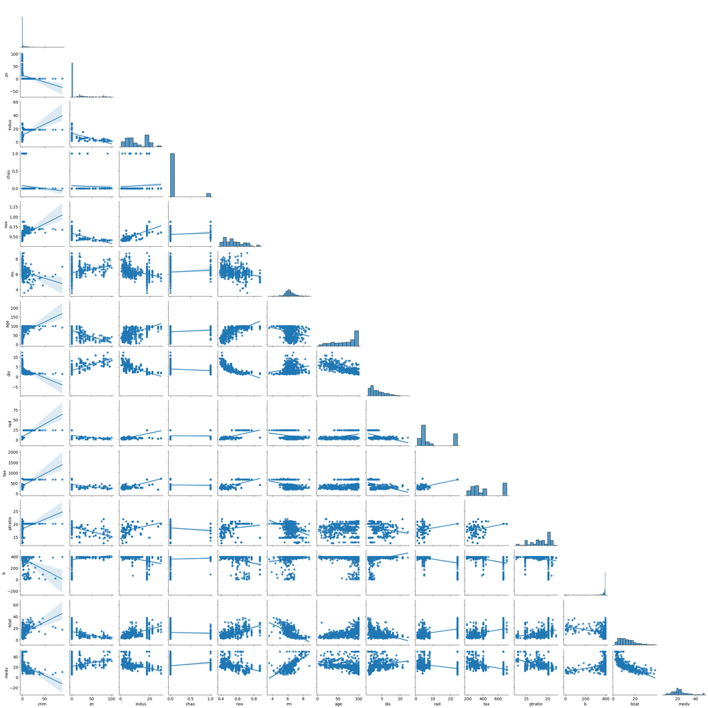

```python
sns.pairplot(pd.concat([features, target], axis=1), kind="reg", corner=True);
```

## Part 1 - full LM

Standartization

```python
means = features.mean(axis=0)
stds = features.std(axis=0)

scaled_features = (features - means) / stds

scaled_features.head()
```

|  | crim | zn | indus | chas | nox | rm | age | dis | rad | tax | ptratio | b | lstat |
| --- | --- | --- | --- | --- | --- | --- | --- | --- | --- | --- | --- | --- | --- |
| 0 | -0.419367 | 0.284548 | -1.286636 | -0.272329 | -0.144075 | 0.413263 | -0.119895 | 0.140075 | -0.981871 | -0.665949 | -1.457558 | 0.440616 | -1.074499 |
| 1 | -0.416927 | -0.487240 | -0.592794 | -0.272329 | -0.739530 | 0.194082 | 0.366803 | 0.556609 | -0.867024 | -0.986353 | -0.302794 | 0.440616 | -0.491953 |
| 2 | -0.416929 | -0.487240 | -0.592794 | -0.272329 | -0.739530 | 1.281446 | -0.265549 | 0.556609 | -0.867024 | -0.986353 | -0.302794 | 0.396035 | -1.207532 |
| 3 | -0.416338 | -0.487240 | -1.305586 | -0.272329 | -0.834458 | 1.015298 | -0.809088 | 1.076671 | -0.752178 | -1.105022 | 0.112920 | 0.415751 | -1.360171 |
| 4 | -0.412074 | -0.487240 | -1.305586 | -0.272329 | -0.834458 | 1.227362 | -0.510674 | 1.076671 | -0.752178 | -1.105022 | 0.112920 | 0.440616 | -1.025487 |

full linear model, not taking into account predictors' interactions

```python
X = sm.add_constant(scaled_features)
model_scaled = sm.OLS(target, X)
results_scaled = model_scaled.fit()

print(results_scaled.summary())
```

```
                            OLS Regression Results
==============================================================================
Dep. Variable:                   medv   R-squared:                       0.741
Model:                            OLS   Adj. R-squared:                  0.734
Method:                 Least Squares   F-statistic:                     108.1
Date:                Wed, 14 Dec 2022   Prob (F-statistic):          6.72e-135
Time:                        21:30:41   Log-Likelihood:                -1498.8
No. Observations:                 506   AIC:                             3026.
Df Residuals:                     492   BIC:                             3085.
Df Model:                          13
Covariance Type:            nonrobust
==============================================================================
                 coef    std err          t      P>|t|      [0.025      0.975]
------------------------------------------------------------------------------
const         22.5328      0.211    106.814      0.000      22.118      22.947
crim          -0.9291      0.283     -3.287      0.001      -1.484      -0.374
zn             1.0826      0.320      3.382      0.001       0.454       1.712
indus          0.1410      0.422      0.334      0.738      -0.688       0.970
chas           0.6824      0.219      3.118      0.002       0.252       1.112
nox           -2.0588      0.443     -4.651      0.000      -2.928      -1.189
rm             2.6769      0.294      9.116      0.000       2.100       3.254
age            0.0195      0.372      0.052      0.958      -0.711       0.750
dis           -3.1071      0.420     -7.398      0.000      -3.932      -2.282
rad            2.6649      0.578      4.613      0.000       1.530       3.800
tax           -2.0788      0.634     -3.280      0.001      -3.324      -0.834
ptratio       -2.0626      0.283     -7.283      0.000      -2.619      -1.506
b              0.8501      0.245      3.467      0.001       0.368       1.332
lstat         -3.7473      0.362    -10.347      0.000      -4.459      -3.036
==============================================================================
Omnibus:                      178.041   Durbin-Watson:                   1.078
Prob(Omnibus):                  0.000   Jarque-Bera (JB):              783.126
Skew:                           1.521   Prob(JB):                    8.84e-171
Kurtosis:                       8.281   Cond. No.                         9.82
==============================================================================

Notes:
[1] Standard Errors assume that the covariance matrix of the errors is correctly specified.
```

```python
target_pred = results_scaled.get_prediction(X).predicted_mean
```

## Part 2 - Model evaluation

### a. Check for linearity

When considering a simple linear regression model, it is important to check the linearity assumption - i.e., that the conditional means of the response variable are a linear function of the predictor variable. Graphing the response variable vs the predictor can often give a good idea of whether or not this is true.

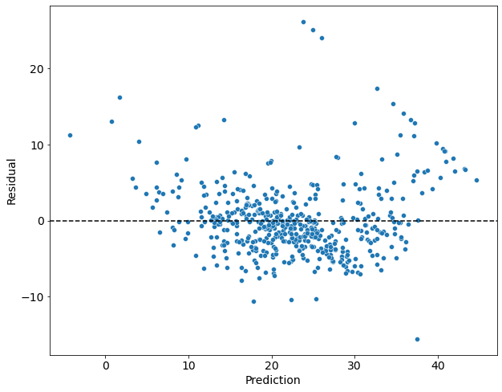

```python
resid_full = target - target_pred
# resid_full = results_scaled.resid #alternative way to count residuals
sns.scatterplot(target_pred, resid_full)
plt.xlabel("Prediction")
plt.ylabel("Residual");
plt.axhline(y=0, color = 'black', linestyle='--');
```

Based on the residuals-over-prediction plot, the dependancy is linear, but doesn't hold for high medv values.

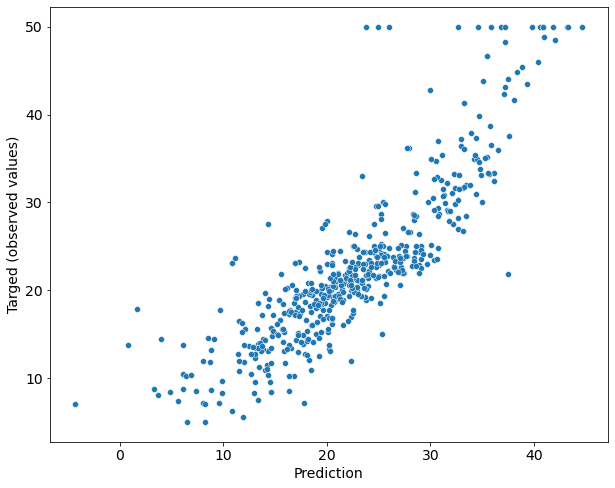

```python
sns.scatterplot(target_pred, target);
plt.xlabel("Prediction");
plt.ylabel("Targed (observed values)");
```

### b. Check for outliers

Let's use Cook distances

```python
influence = results_scaled.get_influence()
cooks = influence.cooks_distance
cooks
```

[output not shown]

[output cut: 174 more lines]

[output not shown]

```python
(cooks[1] < 0.05).sum()
```

```
0
```

### c. Independence of Observations

This is more about study design, but we can at least ensure that all the observations are unique.

```python
df.nunique(axis=1)
```

```
0      14
1      13
2      13
3      13
4      13
       ..
501    13
502    13
503    13
504    13
505    13
Length: 506, dtype: int64
```

All the obs-ns are unique

### d. Check for Normality and Equal Variance

Check for Normality or Other Distribution

Let's use a Q-Q plot and a histogram (although a less robust way) to check out the residuals distribution

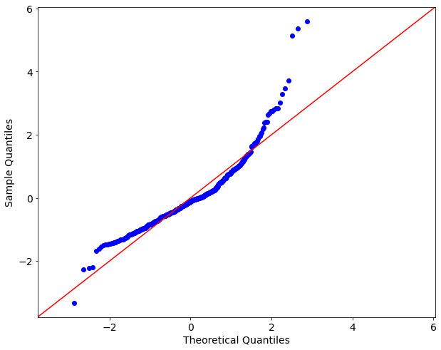

```python
fig = sm.qqplot(resid_full, fit=True, line="45");
plt.show();
```

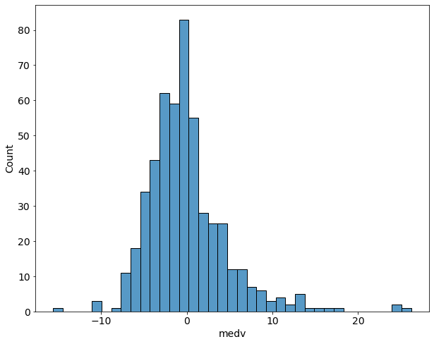

```python
sns.histplot(resid_full);
```

The distribution is close to normal, although the right tail is longer, indicating underestimation by the model.

Equal Variance:

### Check for Multicollinearity

First, let's check the correlation

```python
sns.clustermap(df.corr())
```

[output not shown]

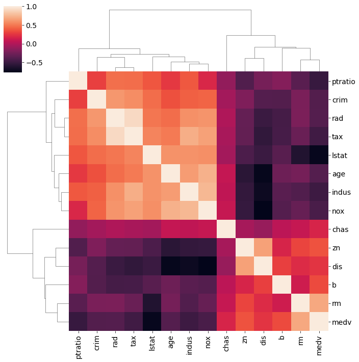

```python
sns.clustermap(df.corr());
```

```python
df.corr()
```

|  | crim | zn | indus | chas | nox | rm | age | dis | rad | tax | ptratio | b | lstat | medv |
| --- | --- | --- | --- | --- | --- | --- | --- | --- | --- | --- | --- | --- | --- | --- |
| crim | 1.000000 | -0.200469 | 0.406583 | -0.055892 | 0.420972 | -0.219247 | 0.352734 | -0.379670 | 0.625505 | 0.582764 | 0.289946 | -0.385064 | 0.455621 | -0.388305 |
| zn | -0.200469 | 1.000000 | -0.533828 | -0.042697 | -0.516604 | 0.311991 | -0.569537 | 0.664408 | -0.311948 | -0.314563 | -0.391679 | 0.175520 | -0.412995 | 0.360445 |
| indus | 0.406583 | -0.533828 | 1.000000 | 0.062938 | 0.763651 | -0.391676 | 0.644779 | -0.708027 | 0.595129 | 0.720760 | 0.383248 | -0.356977 | 0.603800 | -0.483725 |
| chas | -0.055892 | -0.042697 | 0.062938 | 1.000000 | 0.091203 | 0.091251 | 0.086518 | -0.099176 | -0.007368 | -0.035587 | -0.121515 | 0.048788 | -0.053929 | 0.175260 |
| nox | 0.420972 | -0.516604 | 0.763651 | 0.091203 | 1.000000 | -0.302188 | 0.731470 | -0.769230 | 0.611441 | 0.668023 | 0.188933 | -0.380051 | 0.590879 | -0.427321 |
| rm | -0.219247 | 0.311991 | -0.391676 | 0.091251 | -0.302188 | 1.000000 | -0.240265 | 0.205246 | -0.209847 | -0.292048 | -0.355501 | 0.128069 | -0.613808 | 0.695360 |
| age | 0.352734 | -0.569537 | 0.644779 | 0.086518 | 0.731470 | -0.240265 | 1.000000 | -0.747881 | 0.456022 | 0.506456 | 0.261515 | -0.273534 | 0.602339 | -0.376955 |
| dis | -0.379670 | 0.664408 | -0.708027 | -0.099176 | -0.769230 | 0.205246 | -0.747881 | 1.000000 | -0.494588 | -0.534432 | -0.232471 | 0.291512 | -0.496996 | 0.249929 |
| rad | 0.625505 | -0.311948 | 0.595129 | -0.007368 | 0.611441 | -0.209847 | 0.456022 | -0.494588 | 1.000000 | 0.910228 | 0.464741 | -0.444413 | 0.488676 | -0.381626 |
| tax | 0.582764 | -0.314563 | 0.720760 | -0.035587 | 0.668023 | -0.292048 | 0.506456 | -0.534432 | 0.910228 | 1.000000 | 0.460853 | -0.441808 | 0.543993 | -0.468536 |
| ptratio | 0.289946 | -0.391679 | 0.383248 | -0.121515 | 0.188933 | -0.355501 | 0.261515 | -0.232471 | 0.464741 | 0.460853 | 1.000000 | -0.177383 | 0.374044 | -0.507787 |
| b | -0.385064 | 0.175520 | -0.356977 | 0.048788 | -0.380051 | 0.128069 | -0.273534 | 0.291512 | -0.444413 | -0.441808 | -0.177383 | 1.000000 | -0.366087 | 0.333461 |
| lstat | 0.455621 | -0.412995 | 0.603800 | -0.053929 | 0.590879 | -0.613808 | 0.602339 | -0.496996 | 0.488676 | 0.543993 | 0.374044 | -0.366087 | 1.000000 | -0.737663 |
| medv | -0.388305 | 0.360445 | -0.483725 | 0.175260 | -0.427321 | 0.695360 | -0.376955 | 0.249929 | -0.381626 | -0.468536 | -0.507787 | 0.333461 | -0.737663 | 1.000000 |

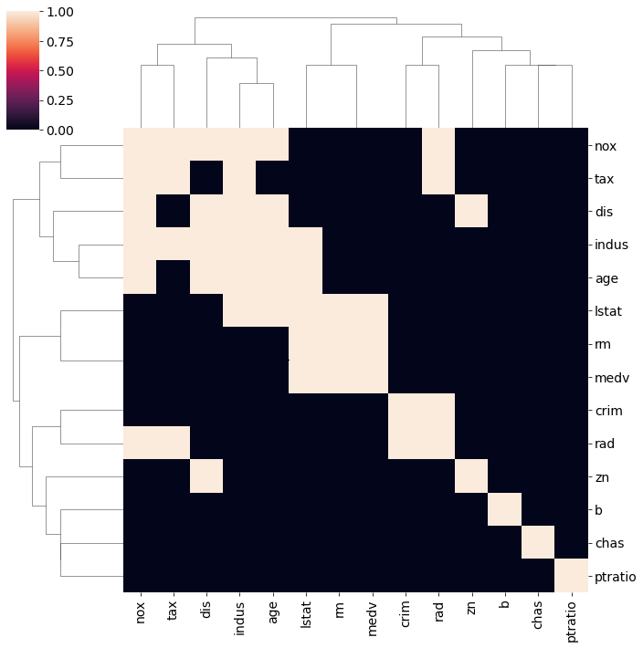

```python
sns.clustermap(df.corr().abs() > 0.6);
```

Unfortunately, quite many independent variables are correlated.

VIF

```python
from statsmodels.stats.outliers_influence import variance_inflation_factor
```

```python
vif_data = pd.DataFrame()
vif_data["feature"] = X.columns
vif_data["VIF"] = [variance_inflation_factor(X.values, i)
                          for i in range(len(X.columns))]

vif_data.sort_values(by='VIF')
```

|  | feature | VIF |
| --- | --- | --- |
| 0 | const | 1.000000 |
| 4 | chas | 1.073995 |
| 12 | b | 1.348521 |
| 1 | crim | 1.792192 |
| 11 | ptratio | 1.799084 |
| 6 | rm | 1.933744 |
| 2 | zn | 2.298758 |
| 13 | lstat | 2.941491 |
| 7 | age | 3.100826 |
| 8 | dis | 3.955945 |
| 3 | indus | 3.991596 |
| 5 | nox | 4.393720 |
| 9 | rad | 7.484496 |
| 10 | tax | 9.008554 |

## Part 3

Plot predicted values over the predictor with the highest absolute coefficient.

Visualize the coefficients:

lsstat has the highest coeff

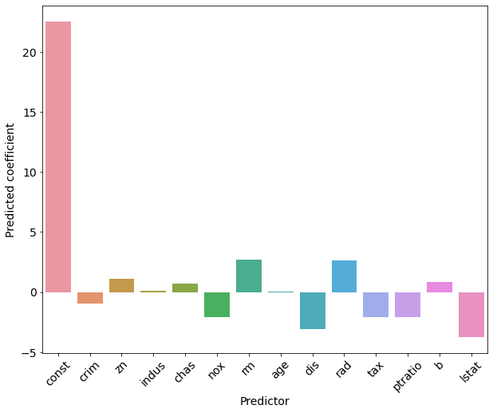

```python
sns.barplot(results_scaled.params.index, results_scaled.params);
plt.xticks(rotation=45);
plt.xlabel("Predictor")
plt.ylabel("Predicted coefficient");
```

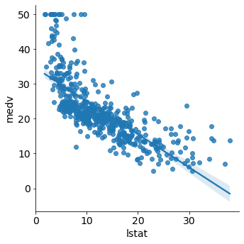

```python
sns.lmplot(x='lstat', y='medv', data=df);
```

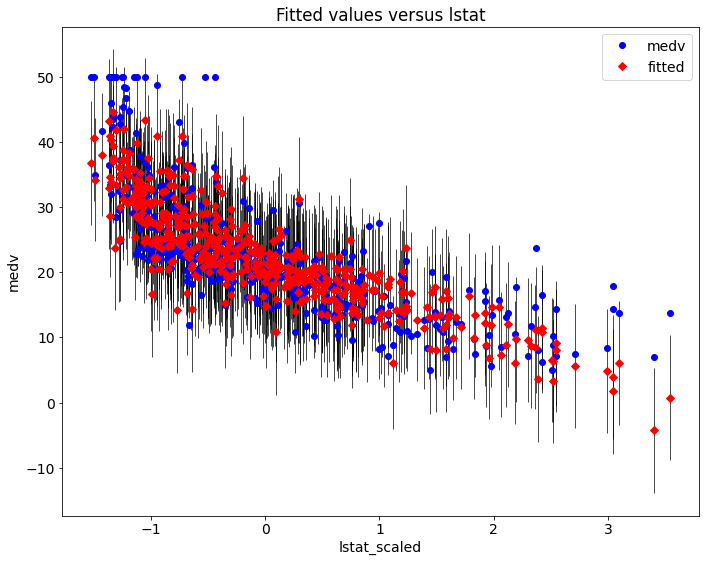

```python
# We can also use plot_fit function
fig = sm.graphics.plot_fit(results_scaled, "lstat")
fig.tight_layout(pad=1.0)
plt.xlabel("lstat_scaled");
```

## Optional

Let's find the most influential predictors.

We'll drop the variables by one, until all the VIF values become adequate (< 2)

```python
def calculate_vif(X):
    vif_data = pd.DataFrame()
    vif_data["feature"] = X.columns
    vif_data["VIF"] = [variance_inflation_factor(X.values, i)
                            for i in range(len(X.columns))]

    return vif_data
```

```python
model_updated = sm.OLS(target, X.drop(columns=['tax']))
results_updated = model_updated.fit()

print(results_updated.summary())
```

```
                            OLS Regression Results
==============================================================================
Dep. Variable:                   medv   R-squared:                       0.735
Model:                            OLS   Adj. R-squared:                  0.729
Method:                 Least Squares   F-statistic:                     113.9
Date:                Wed, 14 Dec 2022   Prob (F-statistic):          1.21e-133
Time:                        22:15:06   Log-Likelihood:                -1504.3
No. Observations:                 506   AIC:                             3035.
Df Residuals:                     493   BIC:                             3089.
Df Model:                          12
Covariance Type:            nonrobust
==============================================================================
                 coef    std err          t      P>|t|      [0.025      0.975]
------------------------------------------------------------------------------
const         22.5328      0.213    105.772      0.000      22.114      22.951
crim          -0.9181      0.285     -3.216      0.001      -1.479      -0.357
zn             0.8483      0.315      2.692      0.007       0.229       1.467
indus         -0.4650      0.383     -1.214      0.225      -1.218       0.288
chas           0.7694      0.219      3.507      0.000       0.338       1.200
nox           -2.1671      0.446     -4.862      0.000      -3.043      -1.291
rm             2.7484      0.296      9.294      0.000       2.167       3.329
age           -0.0170      0.375     -0.045      0.964      -0.754       0.720
dis           -3.1339      0.424     -7.390      0.000      -3.967      -2.301
rad            1.1718      0.359      3.262      0.001       0.466       1.878
ptratio       -2.1327      0.285     -7.478      0.000      -2.693      -1.572
b              0.8715      0.248      3.521      0.000       0.385       1.358
lstat         -3.7291      0.366    -10.198      0.000      -4.448      -3.011
==============================================================================
Omnibus:                      168.699   Durbin-Watson:                   1.089
Prob(Omnibus):                  0.000   Jarque-Bera (JB):              702.173
Skew:                           1.452   Prob(JB):                    3.35e-153
Kurtosis:                       7.987   Cond. No.                         5.87
==============================================================================

Notes:
[1] Standard Errors assume that the covariance matrix of the errors is correctly specified.
```

```python
calculate_vif(X.drop(columns=['tax', 'nox'])).sort_values(by='VIF')
```

|  | feature | VIF |
| --- | --- | --- |
| 0 | const | 1.000000 |
| 4 | chas | 1.057571 |
| 10 | b | 1.339554 |
| 9 | ptratio | 1.598944 |
| 1 | crim | 1.785343 |
| 5 | rm | 1.904013 |
| 2 | zn | 2.183394 |
| 8 | rad | 2.533616 |
| 3 | indus | 2.872809 |
| 6 | age | 2.875130 |
| 11 | lstat | 2.927273 |
| 7 | dis | 3.641492 |

```python
calculate_vif(X.drop(columns=['tax', 'nox', 'dis'])).sort_values(by='VIF')
```

|  | feature | VIF |
| --- | --- | --- |
| 0 | const | 1.000000 |
| 4 | chas | 1.056840 |
| 9 | b | 1.339553 |
| 8 | ptratio | 1.530992 |
| 2 | zn | 1.758636 |
| 1 | crim | 1.765881 |
| 5 | rm | 1.879925 |
| 6 | age | 2.423551 |
| 7 | rad | 2.507024 |
| 3 | indus | 2.517520 |
| 10 | lstat | 2.926111 |

```python
calculate_vif(X.drop(columns=['tax', 'nox', 'dis', 'lstat'])).sort_values(by='VIF')
```

|  | feature | VIF |
| --- | --- | --- |
| 0 | const | 1.000000 |
| 4 | chas | 1.053402 |
| 9 | b | 1.304899 |
| 5 | rm | 1.307312 |
| 8 | ptratio | 1.529761 |
| 1 | crim | 1.727110 |
| 2 | zn | 1.751140 |
| 6 | age | 2.038976 |
| 3 | indus | 2.489395 |
| 7 | rad | 2.497242 |

```python
calculate_vif(X.drop(columns=['tax', 'nox', 'dis', 'lstat', 'rad'])).sort_values(by='VIF')
```

|  | feature | VIF |
| --- | --- | --- |
| 0 | const | 1.000000 |
| 4 | chas | 1.052519 |
| 8 | b | 1.251785 |
| 5 | rm | 1.281667 |
| 7 | ptratio | 1.369726 |
| 1 | crim | 1.372553 |
| 2 | zn | 1.738620 |
| 6 | age | 2.026045 |
| 3 | indus | 2.229252 |

```python
calculate_vif(X.drop(columns=['tax', 'nox', 'dis', 'lstat', 'rad', 'indus'])).sort_values(by='VIF')
```

|  | feature | VIF |
| --- | --- | --- |
| 0 | const | 1.000000 |
| 3 | chas | 1.043732 |
| 7 | b | 1.209887 |
| 4 | rm | 1.216701 |
| 1 | crim | 1.342583 |
| 6 | ptratio | 1.345528 |
| 5 | age | 1.668190 |
| 2 | zn | 1.680416 |

influence of 'chas' variable: if the town is by the river, the prices are higher

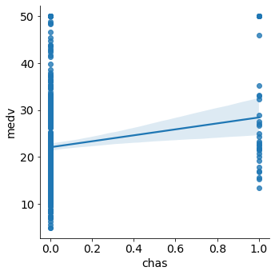

```python
sns.lmplot(x='chas', y='medv', data=df);
```

```python
df_updated = df.drop(columns=['tax', 'nox', 'dis', 'lstat', 'rad', 'indus'])
target_updated = df_updated["medv"]
features_updated = df_updated.loc[:, df_updated.columns != 'medv']
```

```python
X = sm.add_constant(features_updated)
model_upd = sm.OLS(target_updated, X)
results_upd = model_upd.fit()

print(results_upd.summary())
```

```
                            OLS Regression Results
==============================================================================
Dep. Variable:                   medv   R-squared:                       0.637
Model:                            OLS   Adj. R-squared:                  0.632
Method:                 Least Squares   F-statistic:                     124.8
Date:                Wed, 14 Dec 2022   Prob (F-statistic):          2.68e-105
Time:                        23:07:41   Log-Likelihood:                -1583.9
No. Observations:                 506   AIC:                             3184.
Df Residuals:                     498   BIC:                             3218.
Df Model:                           7
Covariance Type:            nonrobust
==============================================================================
                 coef    std err          t      P>|t|      [0.025      0.975]
------------------------------------------------------------------------------
const         -7.0595      4.175     -1.691      0.091     -15.262       1.143
crim          -0.1078      0.033     -3.221      0.001      -0.173      -0.042
zn            -0.0031      0.014     -0.225      0.822      -0.030       0.024
chas           3.5203      0.999      3.524      0.000       1.558       5.483
rm             7.0642      0.390     18.120      0.000       6.298       7.830
age           -0.0414      0.011     -3.637      0.000      -0.064      -0.019
ptratio       -0.9279      0.133     -6.974      0.000      -1.189      -0.667
b              0.0150      0.003      5.008      0.000       0.009       0.021
==============================================================================
Omnibus:                      284.167   Durbin-Watson:                   0.863
Prob(Omnibus):                  0.000   Jarque-Bera (JB):             3023.018
Skew:                           2.242   Prob(JB):                         0.00
Kurtosis:                      14.103   Cond. No.                     6.32e+03
==============================================================================

Notes:
[1] Standard Errors assume that the covariance matrix of the errors is correctly specified.
[2] The condition number is large, 6.32e+03. This might indicate that there are
strong multicollinearity or other numerical problems.
```

medv = -7.06 - 0.11 *crim + 7.06* rm - 0.04 *age - 0.93* ptratio + 0.015 * black

The recommendations may be:

- to maximize the number of rooms per dwelling (each subsequent room increses the price by 7.06 $1000s)
- choose a location near the Charles River
- choose a town with less pupils in class (low pupil-teacher ratio)
- a low per capita crime rate is better